# Global Air Pollution

Hadassah Krigsman

2023-06-21

```r
city <- read_csv(gzfile('data/city_day_agg_cleaned.csv.gz'), show_col_types = FALSE)
country <- read_csv(gzfile('data/country_day_agg_cleaned.csv.gz'), show_col_types = FALSE)
lockdown_USA_CHE <- read_csv('data/lockdown_dates.csv', show_col_types = FALSE) %>% filter(countryCode == 'USA' | countryCode == 'CHE')
longlat <- read_csv('data/openaq_cities.csv', show_col_types = FALSE)
```

Density distributions for the baseline (January-May, 2017-2019) and 2020 periods of NO2.

```r
city_no2 <- city %>%
  filter(parameter == 'no2') %>%
  filter((('2017-01-01' <= date) & (date <= '2017-05-15')) | (('2018-01-01' <= date) & (date <= '2018-05-15')) | (('2019-01-01' <= date) & (date <= '2019-05-15')) | (('2020-01-01' <= date) & (date <= '2020-05-15'))) %>%
  mutate(year = ifelse((date > '2019-12-31'), "2020", "before 2020")) %>%
  group_by(city_id, year) %>%
  summarize(avg = mean(mean, na.rm = TRUE)) %>%
  group_by(year) %>%
  mutate(avg_by_year = median(avg))
```

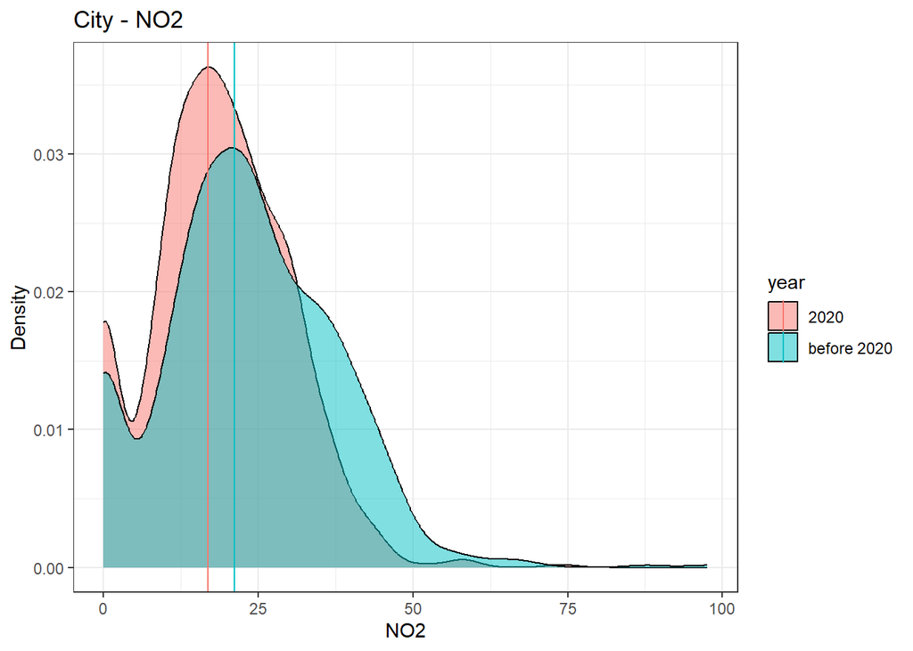

```r
freq_no2 <- table(city_no2$city_id)
city_no2 <- city_no2[city_no2$city_id %in% names(freq_no2)[freq_no2 == 2], ]


city_no2 %>%
  ggplot(aes(x = avg, color = year, fill = year)) +
  geom_density(color = 'black', alpha = 0.5, position = "identity")+
  geom_vline(aes(xintercept = avg_by_year, color = year)) +
  # scale_x_log10()+
  labs(title = "City - NO2",
       x = "NO2",
       y = "Density")
```

Global distribution of 2020 ground-level air pollution anomalies of NO2, with anomalies being defined as deviations in the 2020 January-May averages from the 3-year baseline of the same dates (2017-2019).

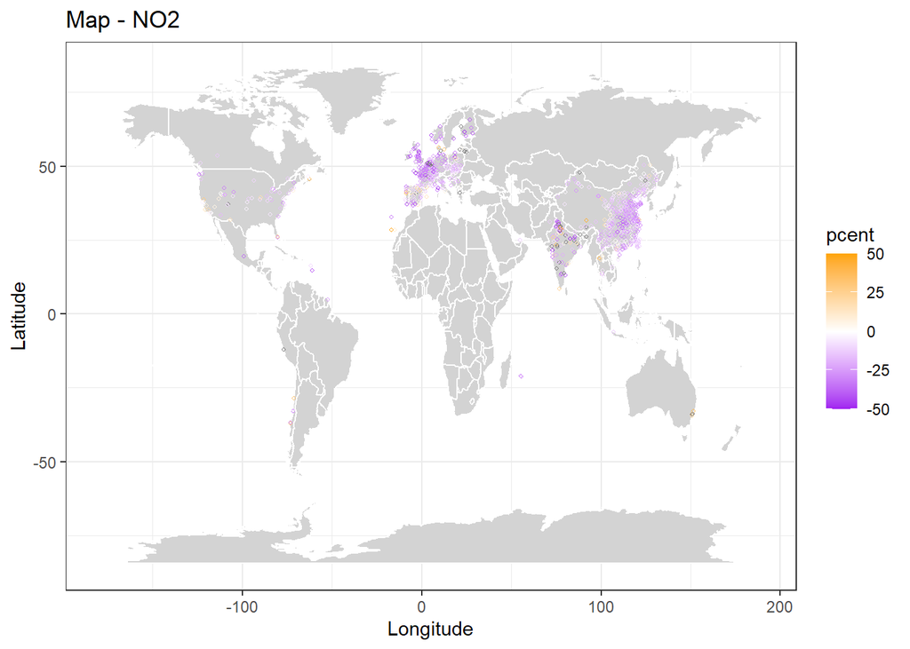

```r
no2_map_2020 <- city %>%
  filter(parameter == 'no2') %>%
  filter((('2020-01-01' <= date) & (date <= '2020-05-15'))) %>%
  group_by(city_id) %>%
  summarize(avg_2020 = mean(mean, na.rm = TRUE))

no2_map_before_2020 <- city %>%
  filter(parameter == 'no2') %>%
  filter((('2017-01-01' <= date) & (date <= '2017-05-15')) | (('2018-01-01' <= date) & (date <= '2018-05-15')) | (('2019-01-01' <= date) & (date <= '2019-05-15'))) %>%
  group_by(city_id) %>%
  summarize(avg_before_2020 = mean(mean, na.rm = TRUE))

no2_map <- inner_join(no2_map_2020, no2_map_before_2020, by = "city_id")
no2_map <- left_join(no2_map, longlat, by = "city_id")
no2_map <- no2_map %>%
  mutate(pcent = ((avg_2020 - avg_before_2020)/avg_before_2020)*100)

world_map <- map_data("world")
ggplot() +
  geom_polygon(data = world_map,
               aes(x = long, y = lat, group = group),
               fill = "lightgray", color = "white") +
  geom_point(data = no2_map,
             aes(x = Lon, y = Lat, color = pcent),
             size = 0.75, pch = 1) +
  scale_color_gradientn(colors = c("purple", "white", "orange"), limits = c(-50, 50)) +
  labs(title = "Map - NO2",
       x = "Longitude",
       y = "Latitude")
```

Density distributions for the baseline (January-May, 2017-2019) and 2020 periods of O3.

```r
city_o3 <- city %>%
  filter(parameter == 'o3') %>%
  filter((('2017-01-01' <= date) & (date <= '2017-05-15')) | (('2018-01-01' <= date) & (date <= '2018-05-15')) | (('2019-01-01' <= date) & (date <= '2019-05-15')) | (('2020-01-01' <= date) & (date <= '2020-05-15'))) %>%
  mutate(year = ifelse((date > '2019-12-31'), "2020", "before 2020")) %>%  group_by(city_id, year) %>%
  summarize(avg = mean(mean, na.rm = TRUE)) %>%
  group_by(year) %>%
  mutate(avg_by_year = median(avg))
```

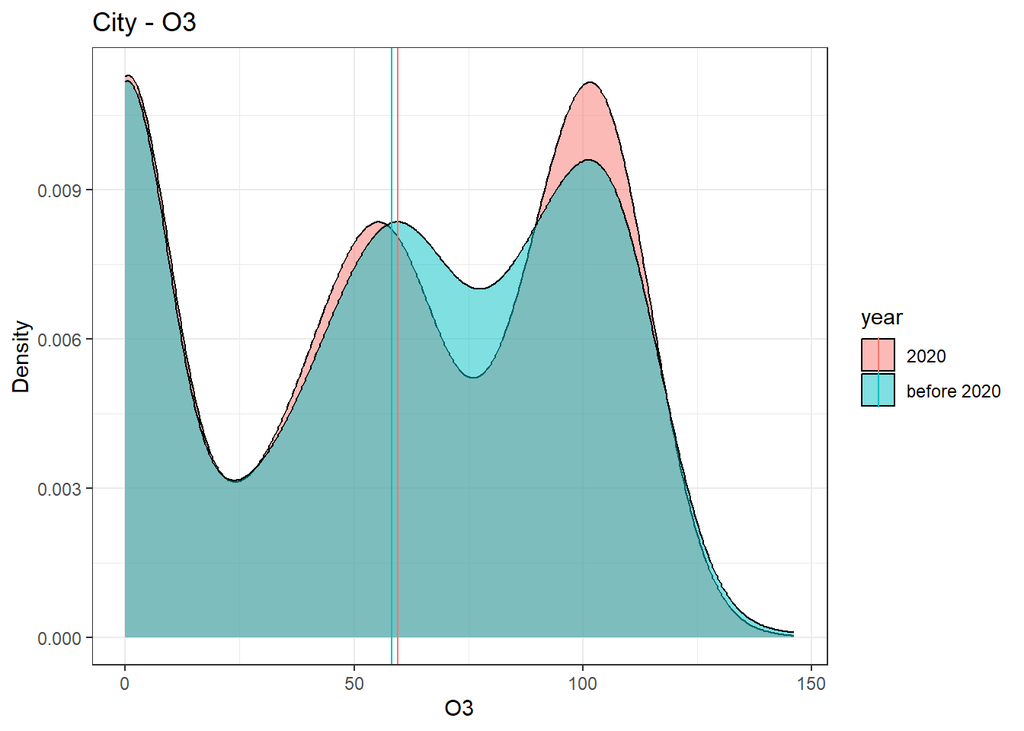

```r
freq_o3 <- table(city_o3$city_id)
city_o3 <- city_o3[city_o3$city_id %in% names(freq_o3)[freq_o3 == 2], ]


city_o3 %>%
  ggplot(aes(x = avg, color = year, fill = year)) +
  geom_density(color = 'black', alpha = 0.5, position = "identity")+
  geom_vline(aes(xintercept = avg_by_year, color = year)) +
  # scale_x_log10()+
  labs(title = "City - O3",
       x = "O3",
       y = "Density")
```

Global distribution of 2020 ground-level air pollution anomalies of O3, with anomalies being defined as deviations in the 2020 January-May averages from the 3-year baseline of the same dates (2017-2019).

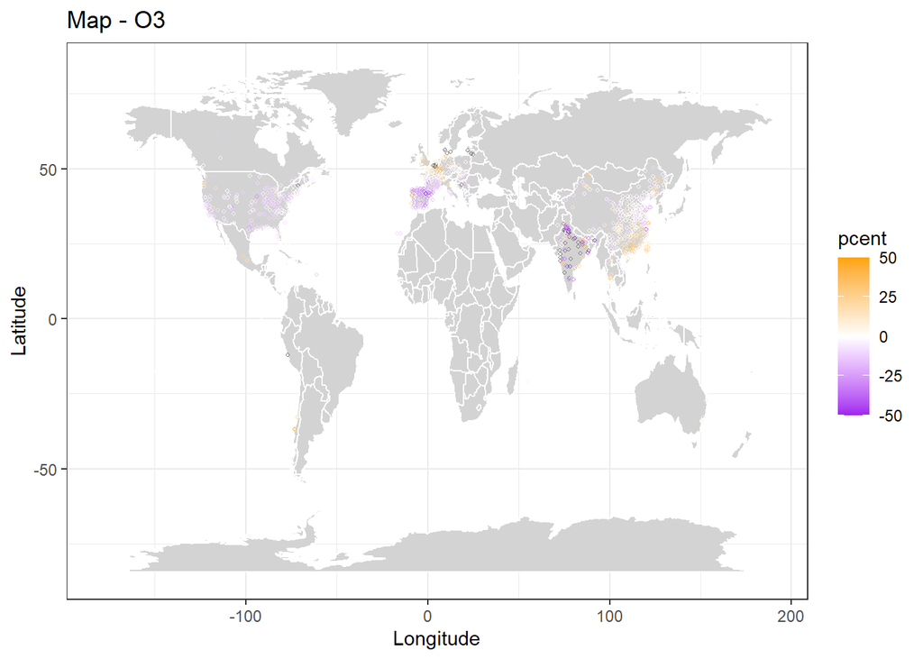

```r
o3_map_2020 <- city %>%
  filter(parameter == 'o3') %>%
  filter((('2020-01-01' <= date) & (date <= '2020-05-15'))) %>%
  group_by(city_id) %>%
  summarize(avg_2020 = mean(mean, na.rm = TRUE))

o3_map_before_2020 <- city %>%
  filter(parameter == 'o3') %>%
  filter((('2017-01-01' <= date) & (date <= '2017-05-15')) | (('2018-01-01' <= date) & (date <= '2018-05-15')) | (('2019-01-01' <= date) & (date <= '2019-05-15'))) %>%
  group_by(city_id) %>%
  summarize(avg_before_2020 = mean(mean, na.rm = TRUE))

o3_map <- inner_join(o3_map_2020, o3_map_before_2020, by = "city_id")
o3_map <- left_join(o3_map, longlat, by = "city_id")
o3_map <- o3_map %>%
  mutate(pcent = ((avg_2020 - avg_before_2020)/avg_before_2020)*100)

world_map <- map_data("world")
ggplot() +
  geom_polygon(data = world_map,
               aes(x = long, y = lat, group = group),
               fill = "lightgray", color = "white") +
  geom_point(data = o3_map,
             aes(x = Lon, y = Lat, color = pcent),
             size = 0.75, pch = 1) +
  scale_color_gradientn(colors = c("purple", "white", "orange"), limits = c(-50, 50)) +
  labs(title = "Map - O3",
       x = "Longitude",
       y = "Latitude")
```

Density distributions for the baseline (January-May, 2017-2019) and 2020 periods of PM2.5.

```r
city_pm <- city %>%
  filter(parameter == 'pm25') %>%
  filter((('2017-01-01' <= date) & (date <= '2017-05-15')) | (('2018-01-01' <= date) & (date <= '2018-05-15')) | (('2019-01-01' <= date) & (date <= '2019-05-15')) | (('2020-01-01' <= date) & (date <= '2020-05-15'))) %>%
  mutate(year = ifelse((date > '2019-12-31'), "2020", "before 2020")) %>%
  group_by(city_id, year) %>%
  summarize(avg = mean(mean, na.rm = TRUE)) %>%
  group_by(year) %>%
  mutate(avg_by_year = median(avg))
```

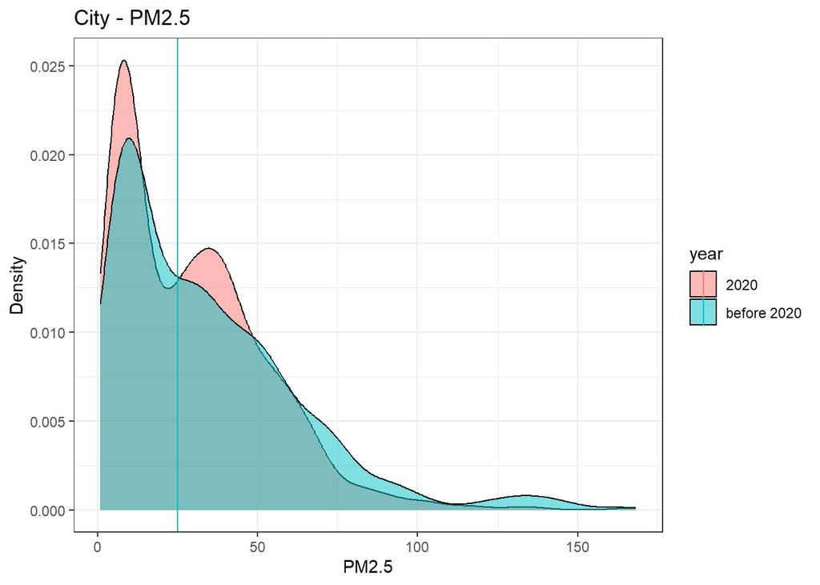

```r
freq_pm <- table(city_pm$city_id)
city_pm <- city_pm[city_pm$city_id %in% names(freq_pm)[freq_pm == 2], ]


city_pm %>%
  ggplot(aes(x = avg, color = year, fill = year)) +
  geom_density(color = 'black', alpha = 0.5, position = "identity")+
  geom_vline(aes(xintercept = avg_by_year, color = year)) +
  # scale_x_log10()+
  labs(title = "City - PM2.5",
       x = "PM2.5",
       y = "Density")
```

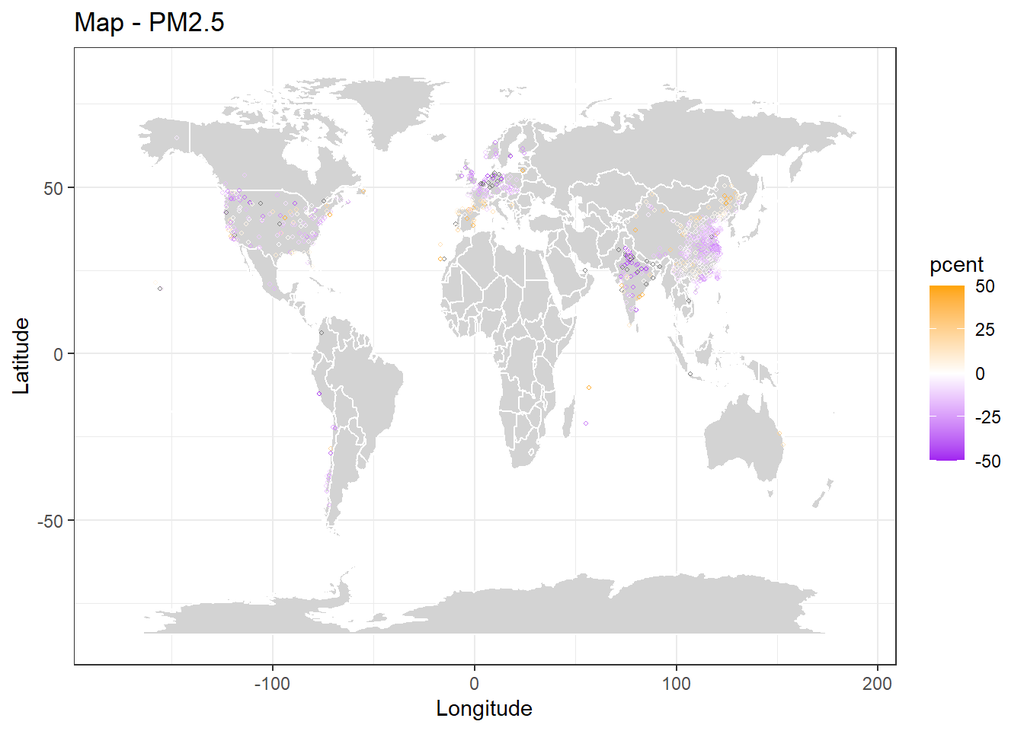

```r
pm_map_2020 <- city %>%
  filter(parameter == 'pm25') %>%
  filter((('2020-01-01' <= date) & (date <= '2020-05-15'))) %>%
  group_by(city_id) %>%
  summarize(avg_2020 = mean(mean, na.rm = TRUE))

pm_map_before_2020 <- city %>%
  filter(parameter == 'pm25') %>%
  filter((('2017-01-01' <= date) & (date <= '2017-05-15')) | (('2018-01-01' <= date) & (date <= '2018-05-15')) | (('2019-01-01' <= date) & (date <= '2019-05-15'))) %>%
  group_by(city_id) %>%
  summarize(avg_before_2020 = mean(mean, na.rm = TRUE))

pm_map <- inner_join(pm_map_2020, pm_map_before_2020, by = "city_id")
pm_map <- left_join(pm_map, longlat, by = "city_id")
pm_map <- pm_map %>%
  mutate(pcent = ((avg_2020 - avg_before_2020)/avg_before_2020)*100)

world_map <- map_data("world")
ggplot() +
  geom_polygon(data = world_map,
               aes(x = long, y = lat, group = group),
               fill = "lightgray", color = "white") +
  geom_point(data = pm_map,
             aes(x = Lon, y = Lat, color = pcent),
             size = 0.75, pch = 1) +
  scale_color_gradientn(colors = c("purple", "white", "orange"), limits = c(-50,50)) +
  labs(title = "Map - PM2.5",
       x = "Longitude",
       y = "Latitude")
```

Country-specific ground-level lockdown air pollution anomalies for PM2.5. The relative change [(observed - benchmark/observed)*100] is plotted here for the US and Switzerland.

```r
model_baseline <- city %>%
  filter(countryCode == 'USA' | countryCode == 'CHE', parameter == 'pm25') %>%
  filter((('2017-03-15' <= date) & (date <= '2017-05-15')) | (('2018-03-15' <= date) & (date <= '2018-05-15')) | (('2019-03-15' <= date) & (date <= '2019-05-15'))) %>%
  mutate(month = month(date, label=T), weekday = as.factor(weekdays(date, abbreviate=T))) %>%
  mutate(is_weekday = !(weekday == 'Sun' | weekday == 'Sat'))

model <- lm(mean ~ month + is_weekday, model_baseline)

model_2020 <- city %>%
  filter(countryCode == 'USA' | countryCode == 'CHE', parameter == 'pm25') %>%
  filter((('2020-03-15' <= date) & (date <= '2020-05-15'))) %>%
  mutate(month = month(date, label=T), weekday = as.factor(weekdays(date, abbreviate=T))) %>%
  mutate(is_weekday = !(weekday == 'Sun' | weekday == 'Sat'))

preds <- predict(model, newdata = model_2020, se.fit = T)
summary(model)
```

```
##
## Call:
## lm(formula = mean ~ month + is_weekday, data = model_baseline)
##
## Residuals:
##     Min      1Q  Median      3Q     Max
## -6.6657 -2.5067 -0.6347  1.8711 26.1737
##
## Coefficients:
##                Estimate Std. Error t value Pr(>|t|)
## (Intercept)     6.41134    0.04635 138.335  < 2e-16 ***
## month.L        -0.17042    0.04744  -3.592 0.000329 ***
## month.Q         0.51104    0.03978  12.845  < 2e-16 ***
## is_weekdayTRUE  0.17521    0.05398   3.246 0.001173 **
## ---
## Signif. codes:  0 '***' 0.001 '**' 0.01 '*' 0.05 '.' 0.1 ' ' 1
##
## Residual standard error: 3.418 on 19780 degrees of freedom
## Multiple R-squared:  0.009327,   Adjusted R-squared:  0.009176
## F-statistic: 62.07 on 3 and 19780 DF,  p-value: < 2.2e-16
```

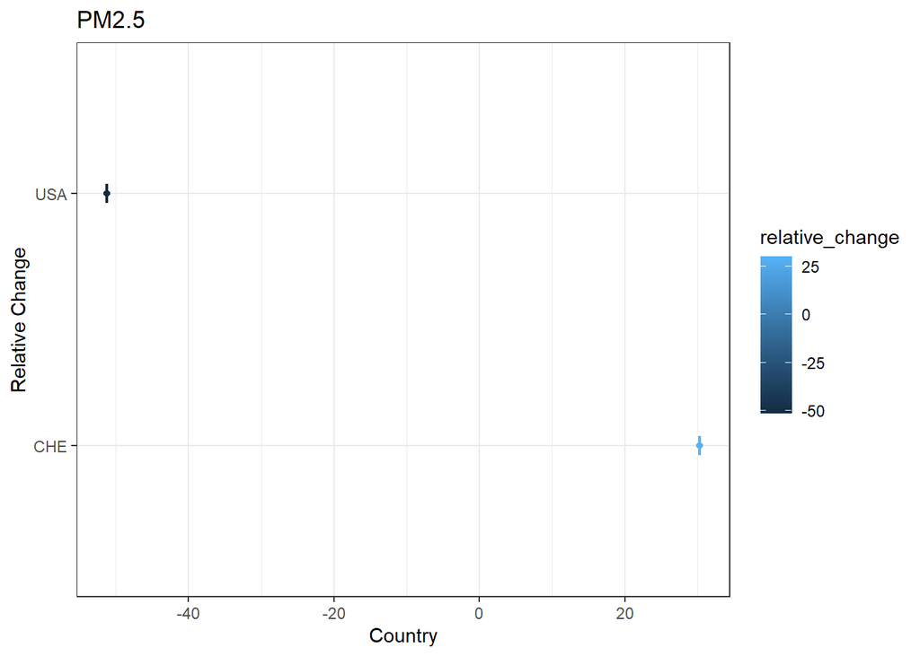

```r
model_2020$pred = preds$fit
model_2020$se = preds$se.fit


pred_model <- model_2020 %>%
  mutate(rc = ((mean - pred)/mean)*100) %>%
  group_by(countryCode) %>%
  summarize(relative_change = mean(rc), mean_se = mean(se)*1.96)


pred_model %>%
  ggplot(aes(x = countryCode, y = relative_change, color = relative_change)) +
  geom_errorbar(aes(ymin = relative_change-mean_se, ymax = relative_change+mean_se), width = 0.075) +
  geom_point() +
  coord_flip() +
  labs(title = "PM2.5",
       x = "Relative Change",
       y = "Country")
```